# Cancer_detection_model

Vijay Mudivedu

2018-09-27

```r
#install.packages("knitr")
#install.packages("tidyverse")
#install.packages("ggbiplot")
#install.packages("reshape2")
#install.packages("randomForest")
#install.packages("kernlab")
#install.packages("glmnet")
#install.packages("caret")
#install.packages(gridExtra)
#install.packages("psych")
library(knitr)
library(tidyverse)
library(reshape2)
library(ggbiplot)
library(randomForest)
library(kernlab)
library(glmnet)
library(caret)
library(gridExtra)
library(psych)
```

## Business Understanding

Features are computed from a digitized image of a fine needle aspirate (FNA) of a breast mass. They describe characteristics of the cell nuclei present in the image.

A diagnostics team is developing a model to classify a tumor as either “benign” or “malignant”.

1. ID number
2. Diagnosis (M = malignant, B = benign) Ten real-valued features are computed for each cell nucleus:
1. radius (mean of distances from center to points on the perimeter)
2. texture (standard deviation of gray-scale values)
3. perimeterj
4. area
5. smoothness (local variation in radius lengths)
6. compactness (perimeter^2 / area - 1.0)
7. concavity (severity of concave portions of the contour)
8. concave points (number of concave portions of the contour)
9. symmetry
10. fractal dimension (“coastline approximation” - 1)

The mean, standard error, and “worst” or largest (mean of the three largest values) of these features were computed for each image, resulting in 30 features. For instance, field 3 is Mean Radius, field 13 is Radius SE, field 23 is Worst Radius. All feature values are recoded with four significant digits.

### Objective of the exercise

1. Conduct an Exploratory Data Analysis and explain your findings.
2. Develop at least three classification models using different machine learning techniques.
3. Explain in detail which model is better and why?
4. Develop principal components for all independent variables, develop the ML models on principal components. Compare these models with previous models. What are the advantages (if any) of using PCA in classification model building?

# ——————

# Data Understanding

# ——————

```r
#install.packages("xlsx")
#install.packages("rJava")
setwd("/Users/vmudivedu/Google Drive/_OneDrive_Atimi_Software/Upgrad/case study/Cancer")
cancer_df_raw <- read.csv(file = "~/Google Drive/_OneDrive_Atimi_Software/Upgrad/case study/Cancer/Worksheet in CaseStudy_Cancer_1.csv",header = T,check.names = T,stringsAsFactors = T)
```

### Data Preparation

- Check for:
- outliers
- NAs
- Duplicates

```r
sum(duplicated(cancer_df_raw$ID)) # no duplicates found
```

```
## [1] 0
```

```r
apply(cancer_df_raw, MARGIN = 2, FUN = function(x) sum(is.na(x))) # no NAs found in the dataset
```

```
##                   ID                  B.M               radius
##                    0                    0                    0
##              texture            perimeter                 area
##                    0                    0                    0
##           smoothness          compactness            concavity
##                    0                    0                    0
##       concave.points             Symmetry    fractal.dimension
##                    0                    0                    0
##            SE.radius           texture.SE         perimeter.SE
##                    0                    0                    0
##              area.SE        smoothness.SE       compactness.SE
##                    0                    0                    0
##         concavity.SE    concave.points.SE          Symmetry.SE
##                    0                    0                    0
## fractal.dimension.SE             radius.W            texture.W
##                    0                    0                    0
##          perimeter.W               area.W         smoothness.W
##                    0                    0                    0
##        compactness.W          concavity.W     concave.points.W
##                    0                    0                    0
##           Symmetry.W  fractal.dimension.W
##                    0                    0
```

- *Normalizing the Parameters*

```r
normalize_func <- function(x)
{
  return((x-min(x))/(max(x)-min(x)))
}

cancer_df <- data.frame( label = cancer_df_raw$B.M ,apply(cancer_df_raw[,-c(1,2)], MARGIN = 2, FUN = function(x) normalize_func(x)))
```

- Shortening the variable names

```r
# Shortening the headers
names(cancer_df)[which(names(cancer_df) %in% c("fractal.dimension","fractal.dimension.SE","fractal.dimension.W"))] <-
   c("fractal.dim","fractal.dim.SE","fractal.dim.W")
```

- Checking the distribution of the diagnosis Class label

```r
table(cancer_df$label)
```

```
##
##   B   M
## 357 212
```

```r
paste(levels(cancer_df$label),"-",round(prop.table(table(cancer_df$label))*100,2),"%")
```

```
## [1] "B - 62.74 %" "M - 37.26 %"
```

- B = 357, 62.74% percent of the cases are benign
- M = 212, 37.26% percent of the cases are Malignant
- *Creating three groups of variable for analysis of mean, se and worst parameter of Breast Cancer dataset*

```r
var_1 <- c("label","radius","texture","perimeter","area","smoothness","compactness","concavity","concave.points","Symmetry","fractal.dim")
var_2 <- c("label","SE.radius","texture.SE","perimeter.SE","area.SE","smoothness.SE","compactness.SE","concavity.SE","concave.points.SE","Symmetry.SE",
           "fractal.dim.SE")
var_3 <- c("label","radius.W", "texture.W","perimeter.W","area.W","smoothness.W","compactness.W","concavity.W","concave.points.W","Symmetry.W","fractal.dim.W")
```

### *Exploratory Data Analysis*

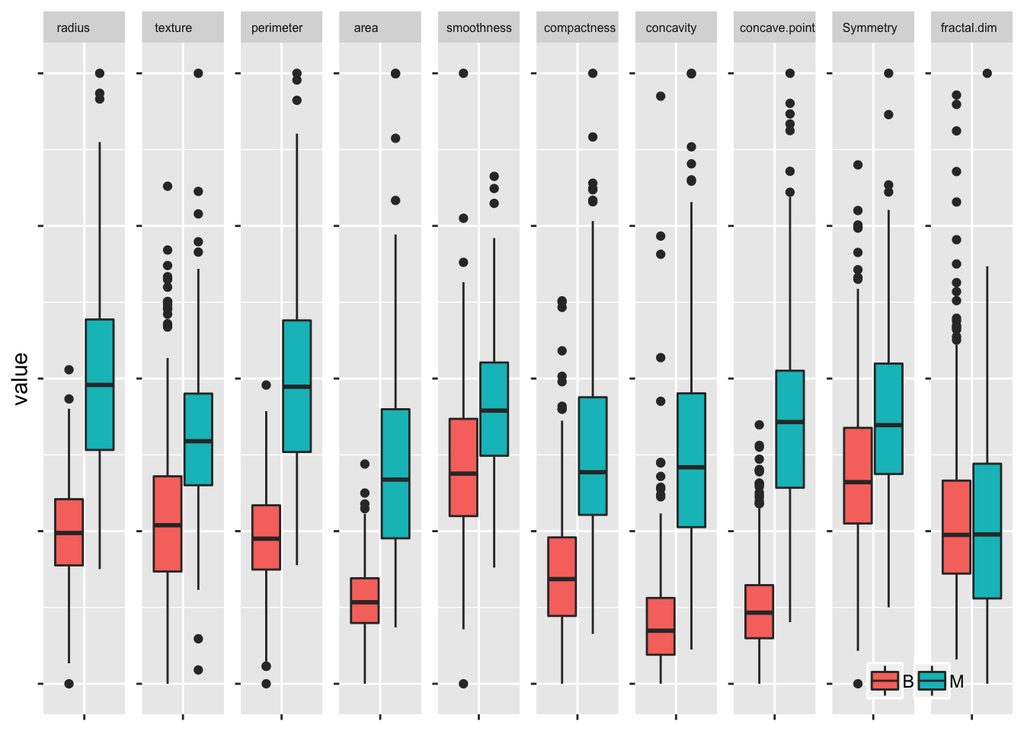

```r
plot1 <- ggplot(data = melt(cancer_df[var_1],id.vars = "label"),aes(variable,value,fill = label)) + geom_boxplot() +
  facet_wrap(facets = variable ~.,scales = "free",nrow = 1) +
  theme(legend.position = c(0.9,0.05),legend.background = element_blank(),legend.title =  element_blank(),legend.direction = "horizontal",
        axis.title.x = element_blank(),axis.text.x = element_blank(), axis.text.y = element_blank(),
        strip.text = element_text(size = 6,hjust = 0.15))

plot1
```

- Green Malignant Tumor, M and Red Records - *Observations*: Parameters of Cancer cells are observed to be larger in values compared to the Benign Cells + Excepting the Fractal.dimesions means of all parameters is higher for a Malignant Breast Cancer cells

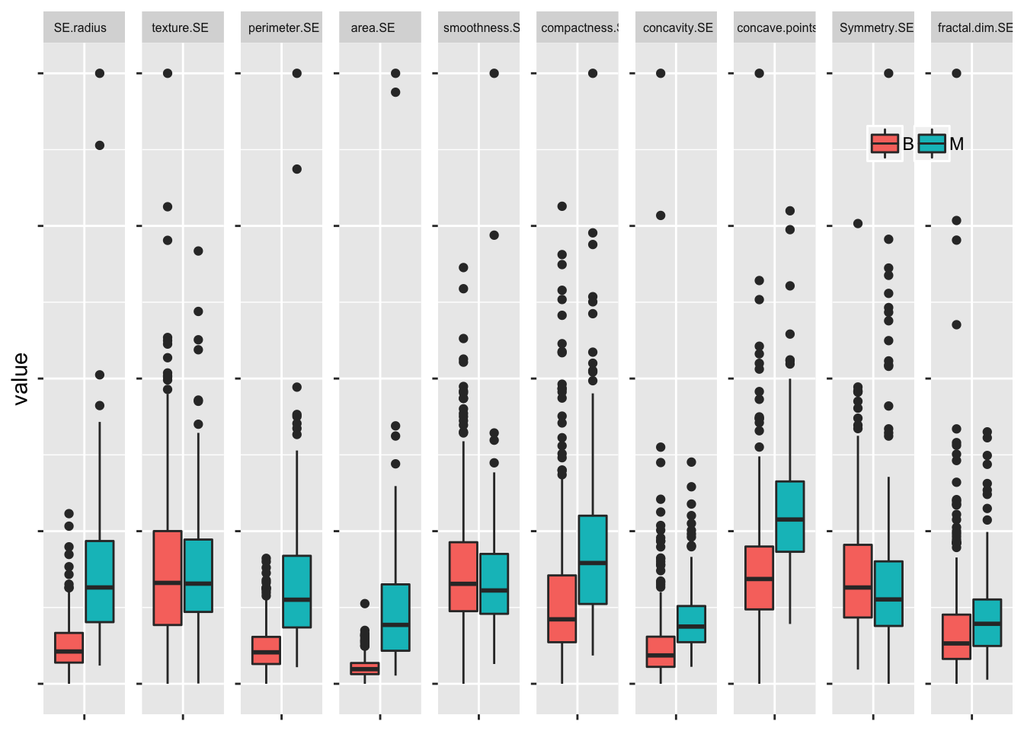

```r
plot2 <- ggplot(data = melt(cancer_df[var_2],id.vars = "label"),aes(variable,value,fill = label)) + geom_boxplot() +
  facet_wrap(facets = variable ~.,scales = "free",nrow = 1) +
  theme(legend.position = c(0.9,0.85),legend.background = element_blank(),legend.title =  element_blank(),legend.direction = "horizontal",
        axis.title.x = element_blank(),axis.text.x = element_blank(), axis.text.y = element_blank(),
        strip.text = element_text(size = 6,hjust = 0.15))

plot2
```

- Standard Error of most parameters for the diagnosed Malignant Breast Cancer cells is higher compared to Benign cells
- Standard error of texture of cells is similar for Malignant and Benign Breast Cancer cells

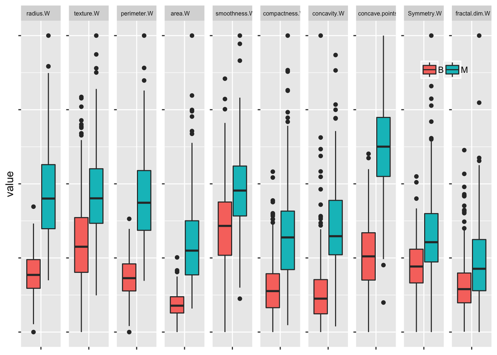

```r
plot3 <- ggplot(data = melt(cancer_df[var_3],id.vars =  "label"),aes(variable,value,fill = label)) + geom_boxplot() +
  facet_wrap(facets = variable ~.,scales = "free",nrow = 1) +
  theme(legend.position = c(0.9,0.85),legend.background = element_blank(),legend.title =  element_blank(),legend.direction = "horizontal",
        axis.title.x = element_blank(),axis.text.x = element_blank(), axis.text.y = element_blank(),
        strip.text = element_text(size = 6,hjust = 0.15))

  plot3
```

- It can be concluded from the boxplots that
- Malignant tumors have larger radius, texture, perimeter, area, compactnes, concavity, concavity points, fact.

*Checking the correlation between the different sets of variables*

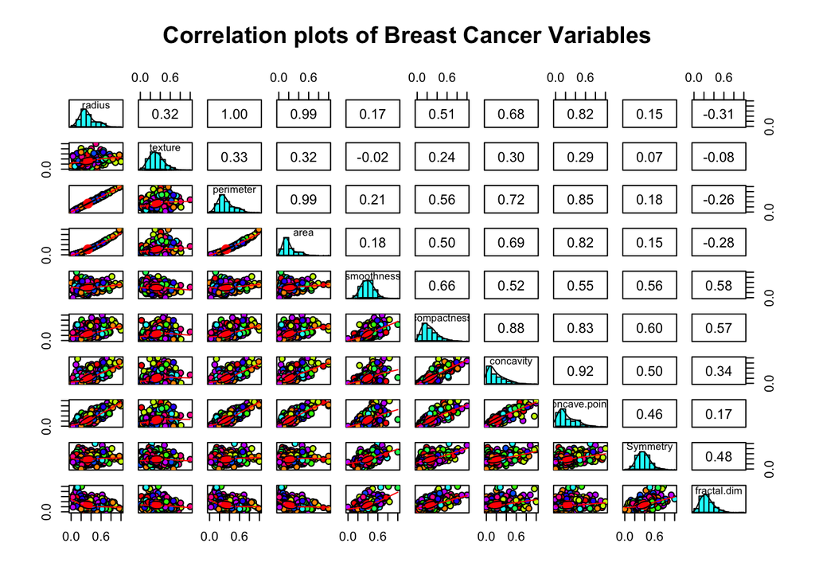

```r
pairs.panels(cancer_df[var_1[-1]],smooth = TRUE,ellipses = TRUE,pch = 21,bg = rainbow(n = length(var_1)-1), main = "Correlation plots of Breast Cancer Variables")
```

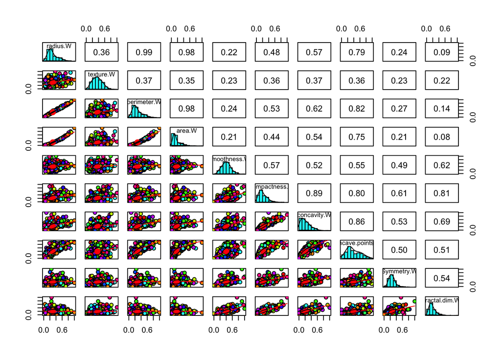

```r
pairs.panels(cancer_df[var_3[-1]],smooth = TRUE,ellipses = TRUE,pch = 21,bg = rainbow(n = length(var_1)-1))
```

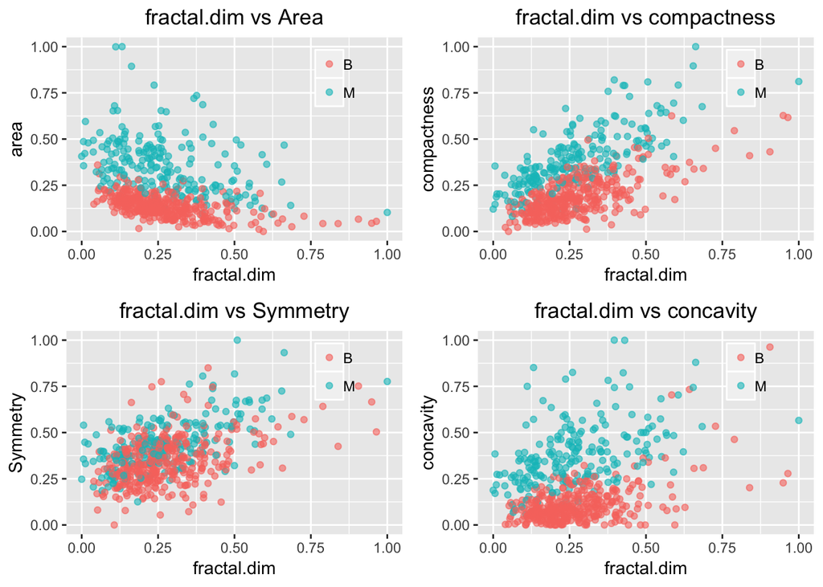

```r
p1 <- ggplot(cancer_df,aes(x = fractal.dim,y = area,col = label)) + geom_point(alpha = 0.6) + labs(title = "fractal.dim vs Area") +
  theme(plot.title = element_text(hjust = 0.5),legend.position =  c(0.8,0.8),legend.background = element_blank(),legend.title =  element_blank())

p2 <- ggplot(cancer_df,aes(x = fractal.dim,y = compactness,col = label)) + geom_point(alpha = 0.6) + labs(title = "fractal.dim vs compactness") +
  theme(plot.title = element_text(hjust = 0.5),legend.position =  c(0.8,0.8),legend.background = element_blank(),legend.title =  element_blank())

p3 <- ggplot(cancer_df,aes(x = fractal.dim,y = Symmetry,col = label)) + geom_point(alpha = 0.6) + labs(title = "fractal.dim vs Symmetry") +
  theme(plot.title = element_text(hjust = 0.5),legend.position =  c(0.8,0.8),legend.background = element_blank(),legend.title =  element_blank())

p4 <- ggplot(cancer_df,aes( x= fractal.dim,y = concavity,col = label)) + geom_point(alpha = 0.6) + labs(title = "fractal.dim vs concavity") +
  theme(plot.title = element_text(hjust = 0.5),legend.position =  c(0.8,0.8),legend.background = element_blank(),legend.title =  element_blank())

gridExtra::grid.arrange(p1,p2,p3,p4)
```

- As it can be seen several of the parameters are exhibit strong correlation with rest of the other parameters
- Fractal dimensions of Malignant Cancer Cells have
- higher values of area, symmetricity, concavity, and compactness against fractal.dimesions are clear indicators of Malignant cells
- inverse relationship with area
- direct relationship with compactness, concavity,Compactness
- Assuming Benign = 0 no cancer case, Malignant = 1 as the case with positive class of breast cancer B = 0, M = 1

```r
diagnosis <- factor(ifelse(test = cancer_df$label == "M",yes = 1,no = 0))
cancer_df$label <- diagnosis
```

*Sampling the dataset and splitting the dataset into train and test*

```r
set.seed(100)
indices_can <- sample(1:nrow(cancer_df),size = 0.7*nrow(cancer_df))
train_df_cancer <- cancer_df[indices_can,]
test_df_cancer <- cancer_df[-indices_can,]
```

*checking the spread of class label*

```r
table(train_df_cancer$label)
```

```
##
##   0   1
## 252 146
```

```r
prop.table(table(train_df_cancer$label))*100 # this is an imbalanced dataset where benign cases are higher than the Malignant tumor cases
```

```
##
##        0        1
## 63.31658 36.68342
```

# (b) Develop at least three classification models using different machine learning techniques.

# ——————-

## Model Building

# ——————-

### Using logistic regression

```r
train_control_logit <- trainControl(method = "repeatedcv",repeats = 5,number = 5,search = "random",allowParallel = TRUE)
model_logit <- caret::train(label~.,data = train_df_cancer[var_2],method = "glm",trControl = train_control_logit)
```

[output not shown]

-Variables in the dataset have a perfect correlation between them, thus using regularization is needed in order to penalize the coefficients that exhibit high degree of collinearlity and leading to overfitting

```r
set.seed(100)
z_predictors <- setdiff(names(train_df_cancer),"label")
#model_lasso <- glmnet::glmnet(x = z_predictors,y = label,,family = "binomial",alpha = 1,lambda = seq(0,0.5,length.out = 50))
model_glmnet <- caret::train(x = train_df_cancer[,z_predictors],y = train_df_cancer[,c("label")],method = "glmnet",
                             trControl = train_control_logit)

model_glmnet
```

```
## glmnet
##
## 398 samples
##  30 predictor
##   2 classes: '0', '1'
##
## No pre-processing
## Resampling: Cross-Validated (5 fold, repeated 5 times)
## Summary of sample sizes: 317, 319, 319, 319, 318, 318, ...
## Resampling results across tuning parameters:
##
##   alpha       lambda      Accuracy   Kappa
##   0.05638315  1.47553079  0.8628268  0.6781687
##   0.25767250  0.06657575  0.9683540  0.9306031
##   0.55232243  0.07636310  0.9547587  0.8998455
##
## Accuracy was used to select the optimal model using the largest value.
## The final values used for the model were alpha = 0.2576725 and lambda
##  = 0.06657575.
```

- With k-fold cross validation, 319 samples were used
- most important predictors

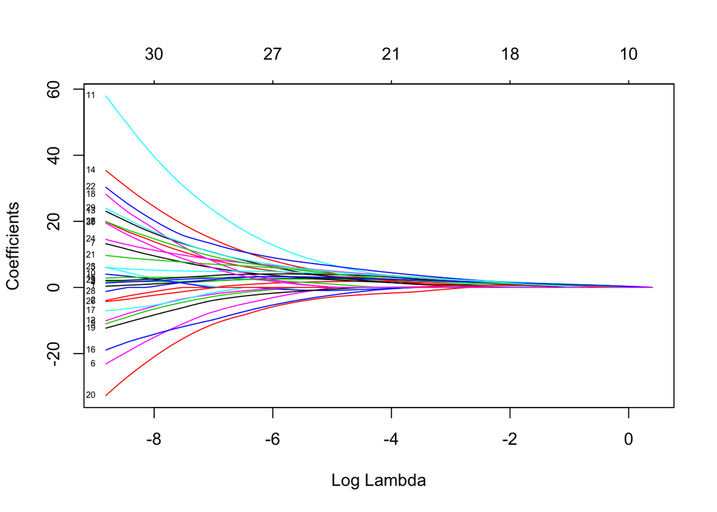

```r
plot(model_glmnet$finalModel,label = T,xvar = "lambda")
```

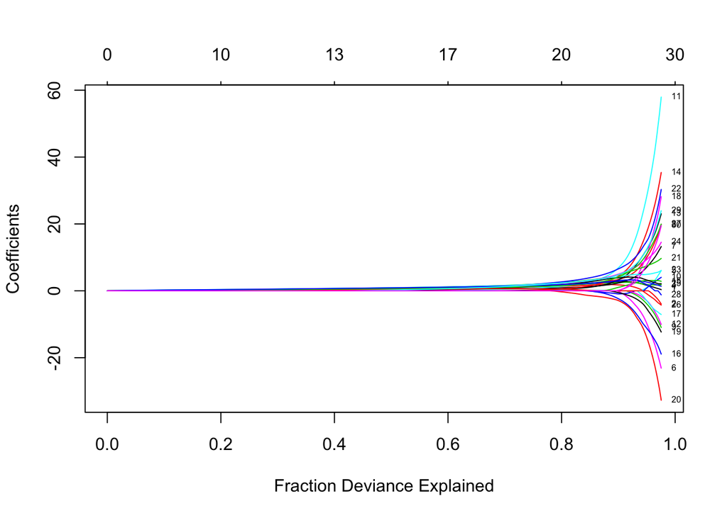

```r
plot(model_glmnet$finalModel,label = T,xvar = "dev")
```

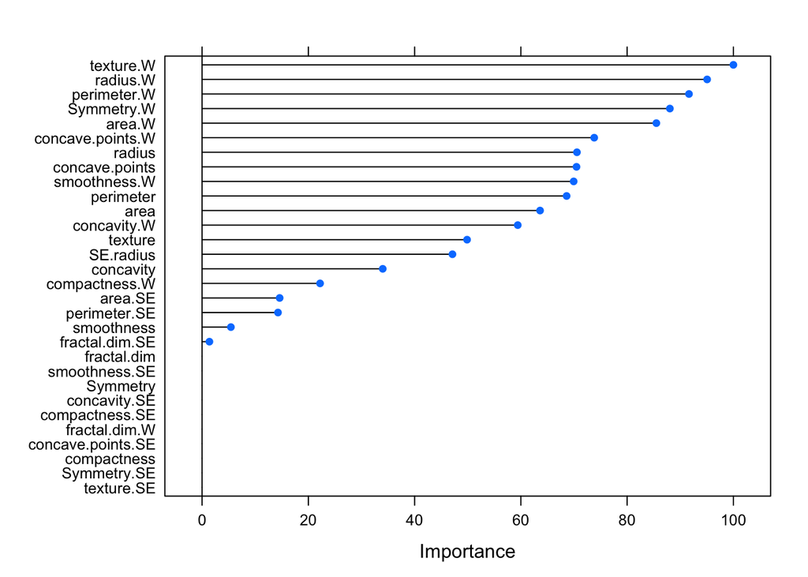

```r
plot(varImp(model_glmnet))
```

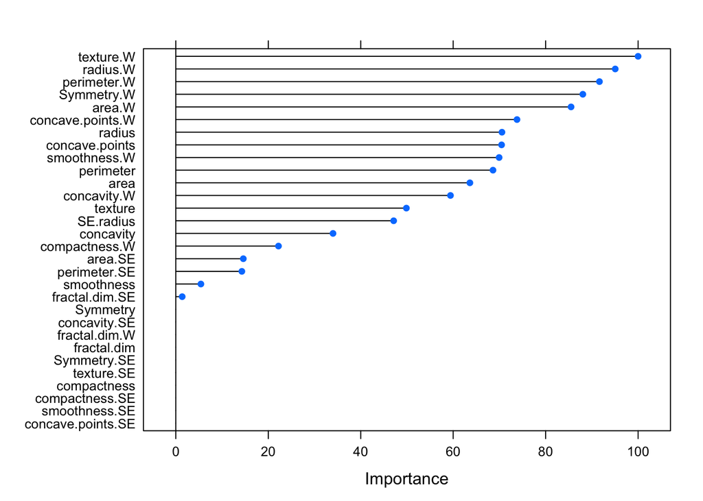

```r
plot(varImp(model_glmnet))
```

```r
varImp(model_glmnet)
```

```
## glmnet variable importance
##
##   only 20 most important variables shown (out of 30)
##
##                  Overall
## texture.W        100.000
## radius.W          95.055
## perimeter.W       91.642
## Symmetry.W        88.047
## area.W            85.501
## concave.points.W  73.804
## radius            70.552
## concave.points    70.472
## smoothness.W      69.938
## perimeter         68.611
## area              63.613
## concavity.W       59.414
## texture           49.874
## SE.radius         47.123
## concavity         34.002
## compactness.W     22.208
## area.SE           14.600
## perimeter.SE      14.284
## smoothness         5.424
## fractal.dim.SE     1.379
```

- The best tuning parameters of ElasticNet Regression are:

```r
model_glmnet$bestTune
```

|  | alpha | lambda |
| --- | --- | --- |
| 2 | 0.2576725 | 0.06657575 |

# predicting the glmnet parameters

```r
predict_glmfit <- predict(object = model_glmnet,newdata = test_df_cancer[z_predictors])#,type = "response")
confusionMatrix(factor(predict_glmfit),test_df_cancer$label,positive = "1")
```

```
## Confusion Matrix and Statistics
##
##           Reference
## Prediction   0   1
##          0 104   4
##          1   1  62
##
##                Accuracy : 0.9708
##                  95% CI : (0.9331, 0.9904)
##     No Information Rate : 0.614
##     P-Value [Acc > NIR] : <2e-16
##
##                   Kappa : 0.9378
##  Mcnemar's Test P-Value : 0.3711
##
##             Sensitivity : 0.9394
##             Specificity : 0.9905
##          Pos Pred Value : 0.9841
##          Neg Pred Value : 0.9630
##              Prevalence : 0.3860
##          Detection Rate : 0.3626
##    Detection Prevalence : 0.3684
##       Balanced Accuracy : 0.9649
##
##        'Positive' Class : 1
##
```

### Using Support Vector Machines

```r
train_control_svm <- trainControl(method = "repeatedcv",
                              repeats = 5,
                              number = 5,
                              search = "grid"
                              )

tuning_grid_svm <- expand.grid(.sigma = seq(0,0.05,0.01),.C = seq(0.1,3,0.5))
# Sigma = non-linearity control parameter
# C = cost function paratmeter to number of misclassifcations control in SVM

model_svm <- ksvm(label ~.,
                  kernel = "polydot", # Radial Basis Function Kernel, Polydot kernels are superior
                  data = train_df_cancer,
                  trControl = trn_cntrol_svm,
                  tuneGrid = tuning_grid_svm,
                  metric = "auc"
                  )
model_svm
```

```
## Support Vector Machine object of class "ksvm"
##
## SV type: C-svc  (classification)
##  parameter : cost C = 1
##
## Polynomial kernel function.
##  Hyperparameters : degree =  1  scale =  1  offset =  1
##
## Number of Support Vectors : 28
##
## Objective Function Value : -16.1825
## Training error : 0.007538
```

```r
# predicting the parameters
predicted_svm <- predict(model_svm,test_df_cancer[z_predictors],type = "response")
# confusion matrix to check the accuracy of the model
confusionMatrix(data = predicted_svm,reference = test_df_cancer$label,positive = "1")
```

```
## Confusion Matrix and Statistics
##
##           Reference
## Prediction   0   1
##          0 101   2
##          1   4  64
##
##                Accuracy : 0.9649
##                  95% CI : (0.9252, 0.987)
##     No Information Rate : 0.614
##     P-Value [Acc > NIR] : <2e-16
##
##                   Kappa : 0.9264
##  Mcnemar's Test P-Value : 0.6831
##
##             Sensitivity : 0.9697
##             Specificity : 0.9619
##          Pos Pred Value : 0.9412
##          Neg Pred Value : 0.9806
##              Prevalence : 0.3860
##          Detection Rate : 0.3743
##    Detection Prevalence : 0.3977
##       Balanced Accuracy : 0.9658
##
##        'Positive' Class : 1
##
```

### Using Random Forest

```r
# Train control
train_control_rf <- trainControl(method = "repeatedcv",
                                  repeats = 5,
                                  number = 5,
                                  search = "grid",
                                  sampling = "smote",
                                 allowParallel = TRUE)

# Tuning grid parameters of Random Forest
tuning_grid_rf <- expand.grid(.mtry = round(sqrt(ncol(train_df_cancer))),ntree = seq(100,500,100))

model_rf <- randomForest(label ~.,
                         data = train_df_cancer,
                         #method = "rf",
                         trControl = train_control_rf,
                         tuneGrid = tuning_grid_rf,
                         metric = "auc")

model_rf$importance
```

```
##                   MeanDecreaseGini
## radius                   7.3953101
## texture                  3.1419139
## perimeter               10.9513108
## area                     8.3137987
## smoothness               1.0772928
## compactness              1.8511822
## concavity                7.4471696
## concave.points          16.9051658
## Symmetry                 0.7149775
## fractal.dim              0.5276583
## SE.radius                1.9118863
## texture.SE               0.7953776
## perimeter.SE             2.6020721
## area.SE                  7.1423376
## smoothness.SE            0.6583737
## compactness.SE           0.8444405
## concavity.SE             1.1100036
## concave.points.SE        0.8458098
## Symmetry.SE              0.6723726
## fractal.dim.SE           0.8097716
## radius.W                18.6198145
## texture.W                3.5228826
## perimeter.W             25.8924795
## area.W                  24.1959641
## smoothness.W             2.0870272
## compactness.W            2.9855770
## concavity.W              8.3902906
## concave.points.W        19.7043292
## Symmetry.W               2.3192125
## fractal.dim.W            0.8539361
```

```r
predict_rf <- stats::predict(object = model_rf,test_df_cancer[z_predictors])

# Confusion Matrix
confusionMatrix(predict_rf,test_df_cancer$label,positive = "1")
```

```
## Confusion Matrix and Statistics
##
##           Reference
## Prediction   0   1
##          0 100   5
##          1   5  61
##
##                Accuracy : 0.9415
##                  95% CI : (0.8951, 0.9716)
##     No Information Rate : 0.614
##     P-Value [Acc > NIR] : <2e-16
##
##                   Kappa : 0.8766
##  Mcnemar's Test P-Value : 1
##
##             Sensitivity : 0.9242
##             Specificity : 0.9524
##          Pos Pred Value : 0.9242
##          Neg Pred Value : 0.9524
##              Prevalence : 0.3860
##          Detection Rate : 0.3567
##    Detection Prevalence : 0.3860
##       Balanced Accuracy : 0.9383
##
##        'Positive' Class : 1
##
```